# Consumo de Gasolina

#### Estimación

Como no es estacionaria en varianza se hizo una transformación logarítmica para hacerla estacionaria en varianza. Se realizó con la serie de entrenamiento que es la que nos ayudará a predecir.

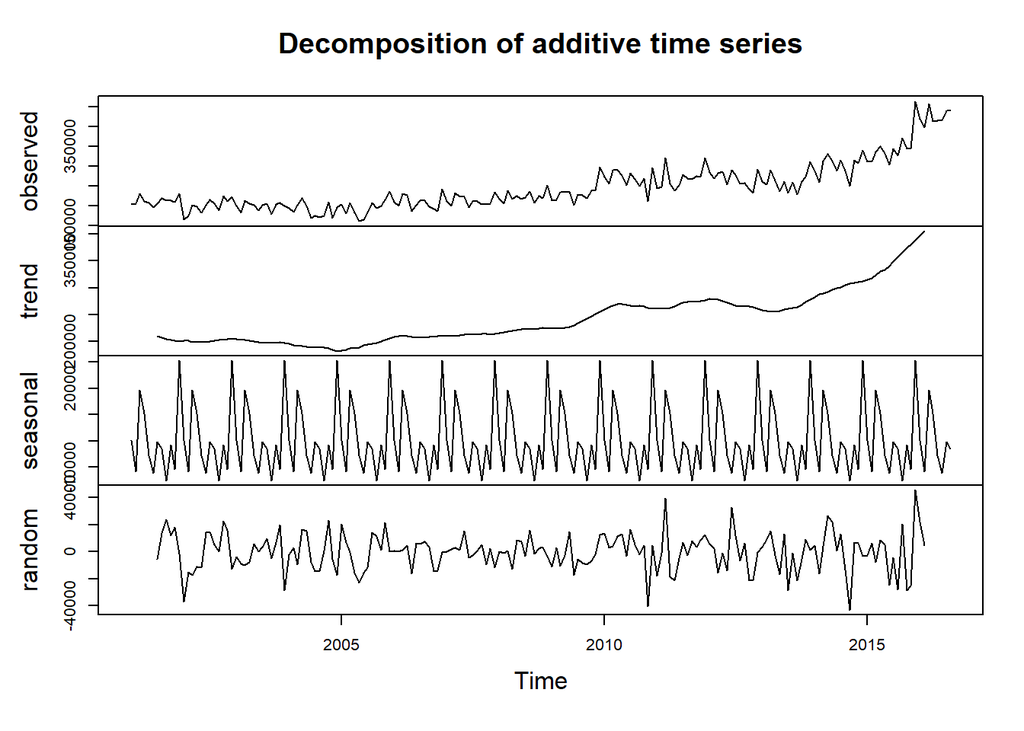

```r
train<-head(regular_ts, round(length(regular_ts) * 0.7))
h<-length(regular_ts) - length(train)
test<-tail(regular_ts, h)

#Aplicaremos una transformación logarítmica
logRegular<-log(train)
plot(decompose(train))
```

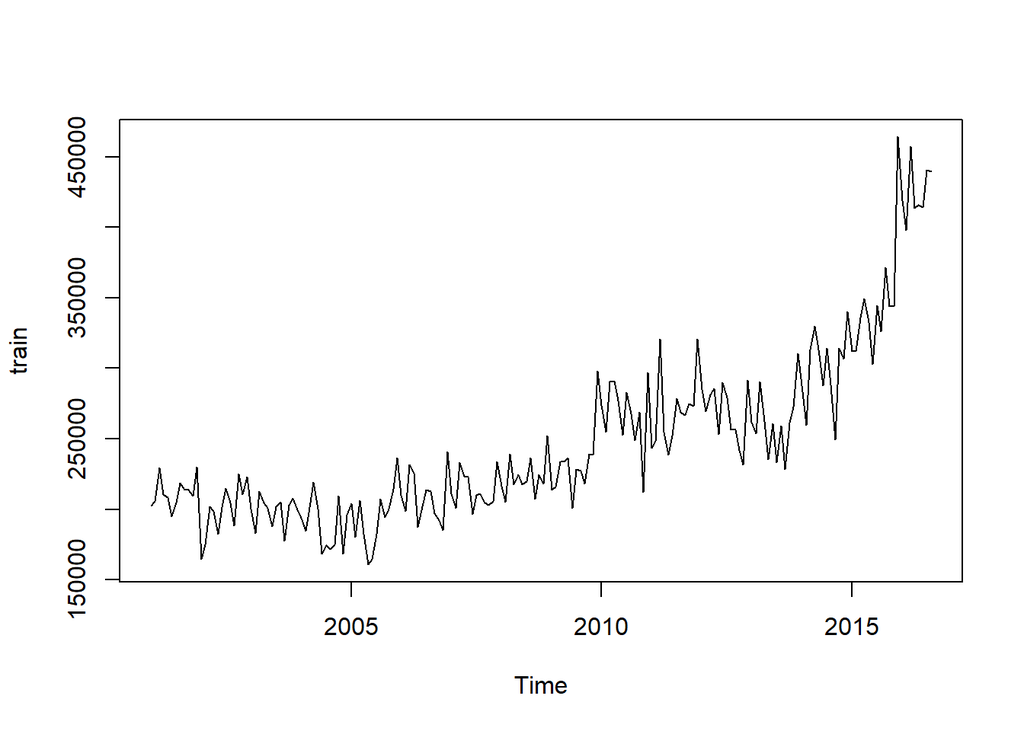

```r
plot(train)
```

```r
#Para saber si hay raíces unitarias
adfTest(train)
```

```
##
## Title:
##  Augmented Dickey-Fuller Test
##
## Test Results:
##   PARAMETER:
##     Lag Order: 1
##   STATISTIC:
##     Dickey-Fuller: 0.7738
##   P VALUE:
##     0.8616
##
## Description:
##  Mon Aug 08 23:41:35 2022 by user: xavih
```

```r
unitrootTest(train)
```

```
##
## Title:
##  Augmented Dickey-Fuller Test
##
## Test Results:
##   PARAMETER:
##     Lag Order: 1
##   STATISTIC:
##     DF: 0.7738
##   P VALUE:
##     t: 0.8797
##     n: 0.869
##
## Description:
##  Mon Aug 08 23:41:35 2022 by user: xavih
```

Se observa que el valor de P es mayor a 0.05 por lo que la hipótesis nula no se rechaza, esto quiere decir que la serie no es estacionaria. Entonces aplicamos diferenciación.

```r
adfTest(diff(train))
```

```
##
## Title:
##  Augmented Dickey-Fuller Test
##
## Test Results:
##   PARAMETER:
##     Lag Order: 1
##   STATISTIC:
##     Dickey-Fuller: -17.9232
##   P VALUE:
##     0.01
##
## Description:
##  Mon Aug 08 23:41:35 2022 by user: xavih
```

```r
unitrootTest(diff(train))
```

```
##
## Title:
##  Augmented Dickey-Fuller Test
##
## Test Results:
##   PARAMETER:
##     Lag Order: 1
##   STATISTIC:
##     DF: -17.9232
##   P VALUE:
##     t: < 2.2e-16
##     n: 0.002672
##
## Description:
##  Mon Aug 08 23:41:35 2022 by user: xavih
```

Ahora el valor de P sí está por debajo de 0.05 y la hipótesis nula se rechaza diciendo que la serie es estacionaria. Ahora pasamos a identificar los parámetros p y q usando los gráficos de autocorrelación y autocorrelación parcial.

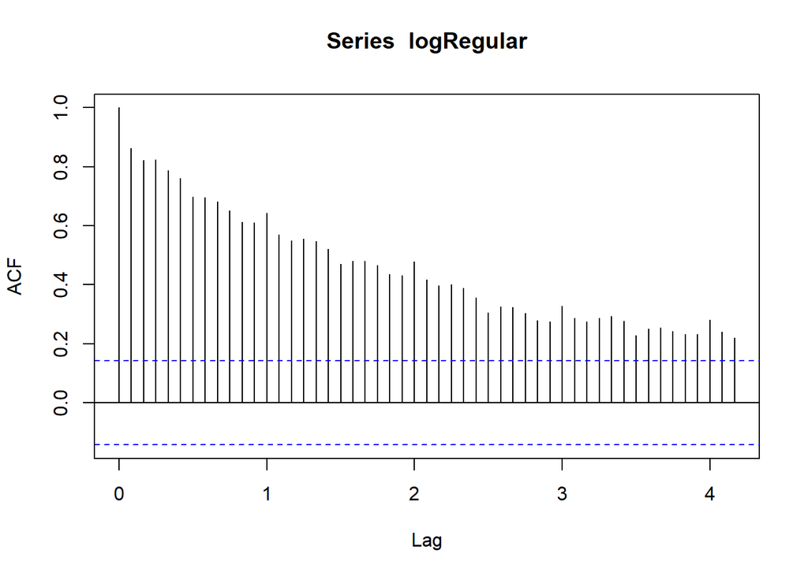

```r
#Gráfico de autocorrelación
acf(logRegular,50)
```

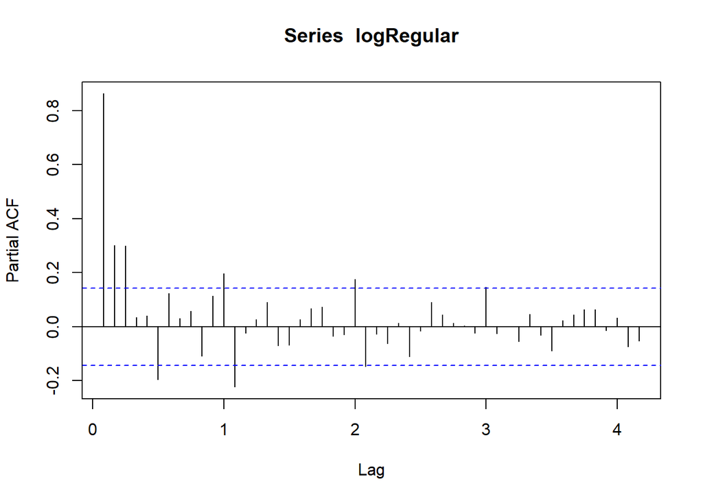

```r
pacf(logRegular,50)
```

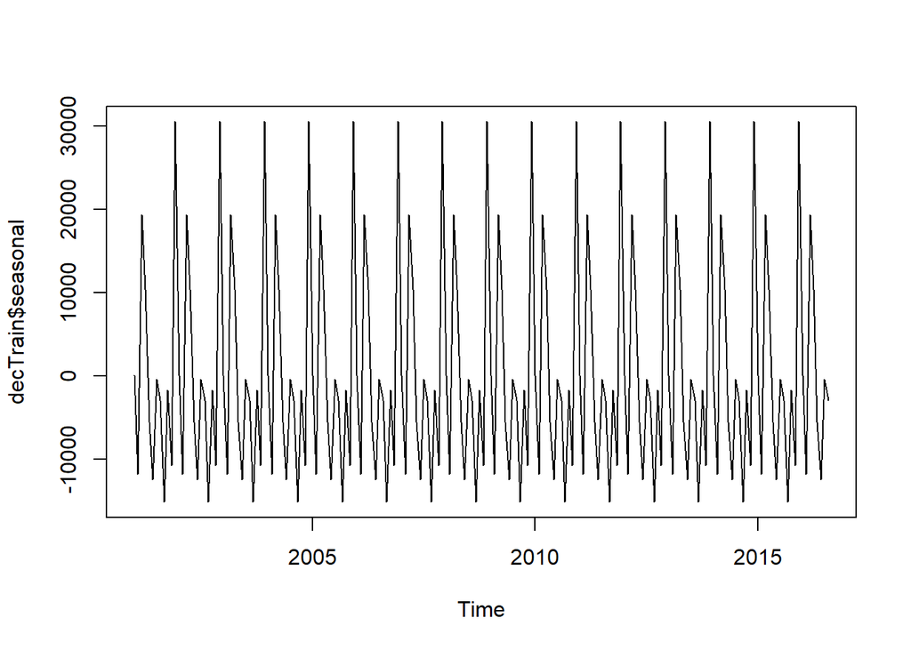

```r
decTrain<-decompose(train)
plot(decTrain$seasonal)
```

Al parecer sí existe estacionalidad en la serie. Para tener una idea de los parámetros estacionales veremos las funciones de autocorrelación y autocorrelación parcial con 36 resagos para ver en qué momentos son los picos estacionales, para ello se usará la serie estacionarizada.

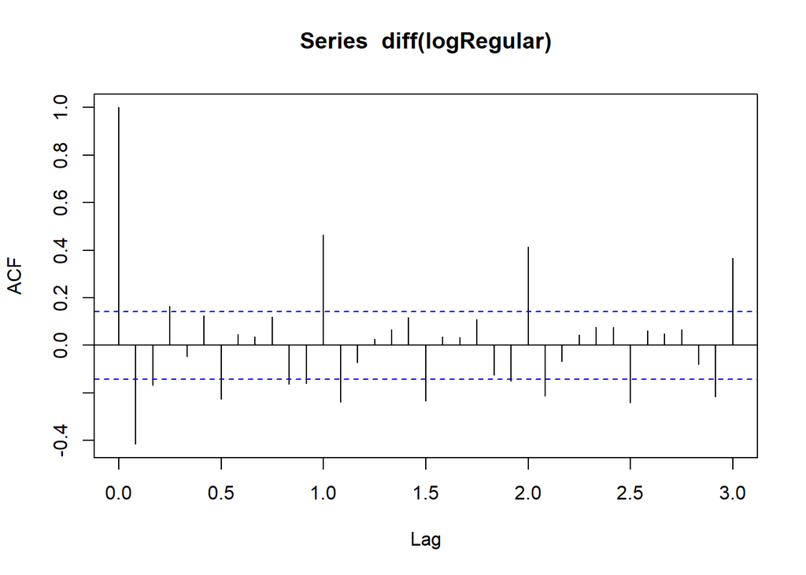

```r
acf(diff(logRegular),36)
```

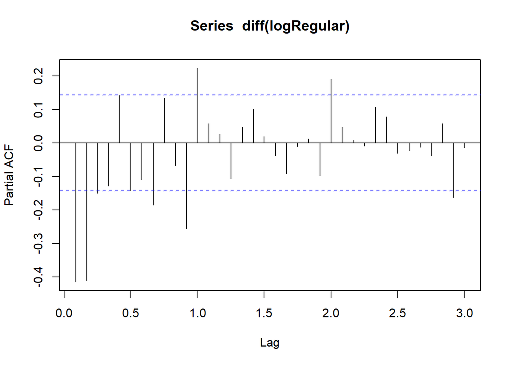

```r
pacf(diff(logRegular),36)
```

```r
fitArima<-arima(logRegular,order=c(2,1,2),seasonal = c(1,1,0))
fitAutoArima<-auto.arima(train)
```

#### Validación

```r
coeftest(fitArima)
```

```
##
## z test of coefficients:
##
##       Estimate Std. Error z value  Pr(>|z|)
## ar1  -0.906105   0.125430 -7.2240 5.049e-13 ***
## ar2  -0.045979   0.124146 -0.3704 0.7111097
## ma1   0.377419   0.106476  3.5446 0.0003931 ***
## ma2  -0.622579   0.105481 -5.9023 3.585e-09 ***
## sar1 -0.484085   0.069631 -6.9521 3.598e-12 ***
## ---
## Signif. codes:  0 '***' 0.001 '**' 0.01 '*' 0.05 '.' 0.1 ' ' 1
```

```r
coeftest(fitAutoArima)
```

```
##
## z test of coefficients:
##
##       Estimate Std. Error  z value  Pr(>|z|)
## ar1  -1.930887   0.111502 -17.3171 < 2.2e-16 ***
## ar2  -1.124874   0.210834  -5.3354 9.535e-08 ***
## ar3  -0.145841   0.113554  -1.2843 0.1990256
## ma1   1.391750   0.097818  14.2280 < 2.2e-16 ***
## ma2  -0.085115   0.179047  -0.4754 0.6345182
## ma3  -0.535855   0.098017  -5.4670 4.578e-08 ***
## sma1  0.296409   0.085427   3.4697 0.0005210 ***
## sma2  0.309018   0.080730   3.8278 0.0001293 ***
## ---
## Signif. codes:  0 '***' 0.001 '**' 0.01 '*' 0.05 '.' 0.1 ' ' 1
```

##### Analisis de residuales

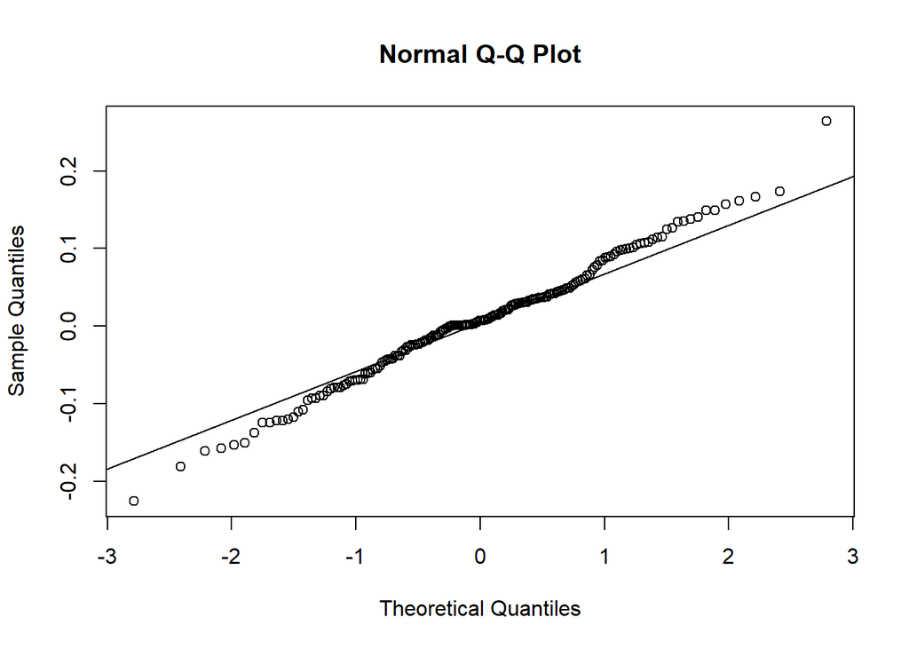

```r
qqnorm(fitArima$residuals)
qqline(fitArima$residuals)
```

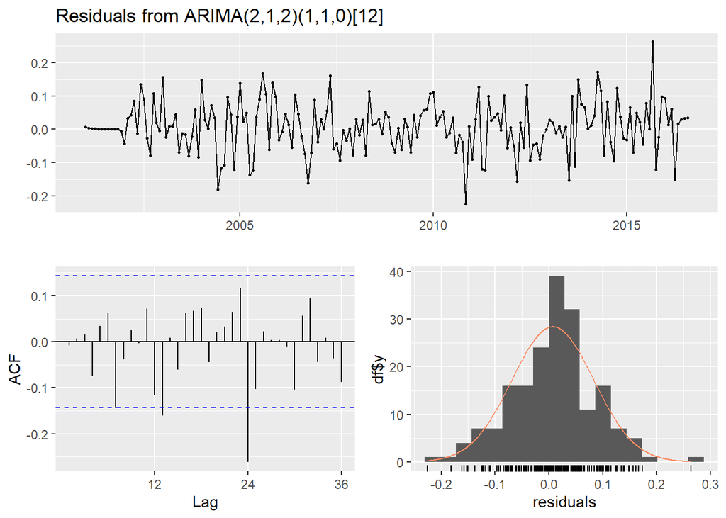

```
##
##  Ljung-Box test
##
## data:  Residuals from ARIMA(2,1,2)(1,1,0)[12]
## Q* = 38.825, df = 19, p-value = 0.004653
##
## Model df: 5.   Total lags used: 24
```

```r
checkresiduals(fitArima)
```

Según el test de Ljung-Box el valor de P es menor a 0.05 por lo que se rechaza la hipótesis nula, lo que significa que los residuos no se distribuyen de forma independiente, exhiben correlación serial.

Ahora analizamos los residuos del modelo generado de forma automática por R.

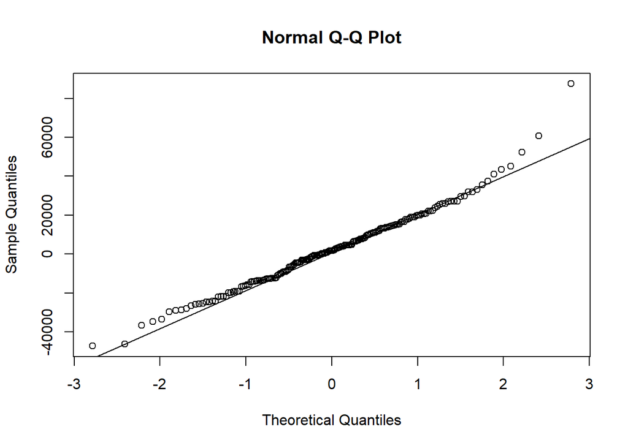

```r
qqnorm(fitAutoArima$residuals)
qqline(fitAutoArima$residuals)
```

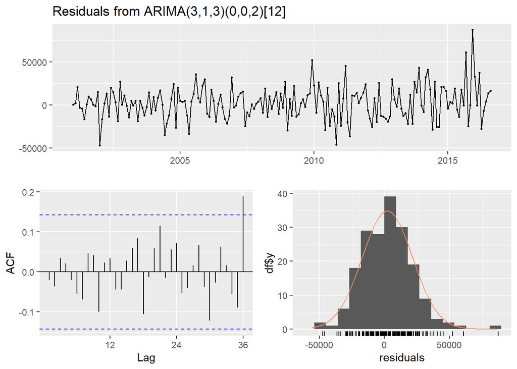

```
##
##  Ljung-Box test
##
## data:  Residuals from ARIMA(3,1,3)(0,0,2)[12]
## Q* = 16.351, df = 16, p-value = 0.4288
##
## Model df: 8.   Total lags used: 24
```

```r
checkresiduals(fitAutoArima)
```

Ahora el valor de P cambió y es mucho mayor a 0.05, entonces no se rechaza la hipótesis nula, lo que nos dice que los residuos del modelo son independientes.

#### Predicción

```r
# Hacer el modelo
auto.arima(regular_ts)
```

```
## Series: regular_ts
## ARIMA(1,1,1)(2,0,0)[12] with drift
##
## Coefficients:
##          ar1      ma1    sar1    sar2     drift
##       0.6105  -0.9093  0.3278  0.3233  2154.787
## s.e.  0.0802   0.0432  0.0654  0.0657  1052.046
##
## sigma^2 = 801643755:  log likelihood = -3128.13
## AIC=6268.25   AICc=6268.57   BIC=6289.8
```

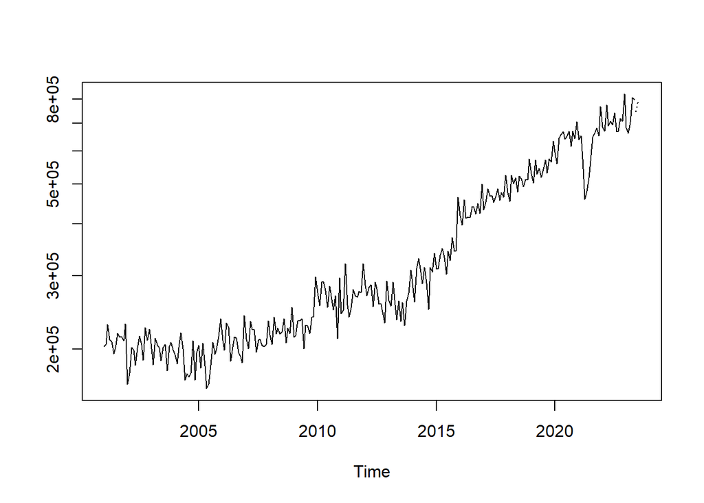

```r
fit<-arima(log(regular_ts), c(0, 1, 1),seasonal = list(order = c(0, 1, 1), period = 12))
pred<-predict(fit, n.ahead = 3)
ts.plot(regular_ts,2.718^pred$pred, log = "y", lty = c(1,3))
```

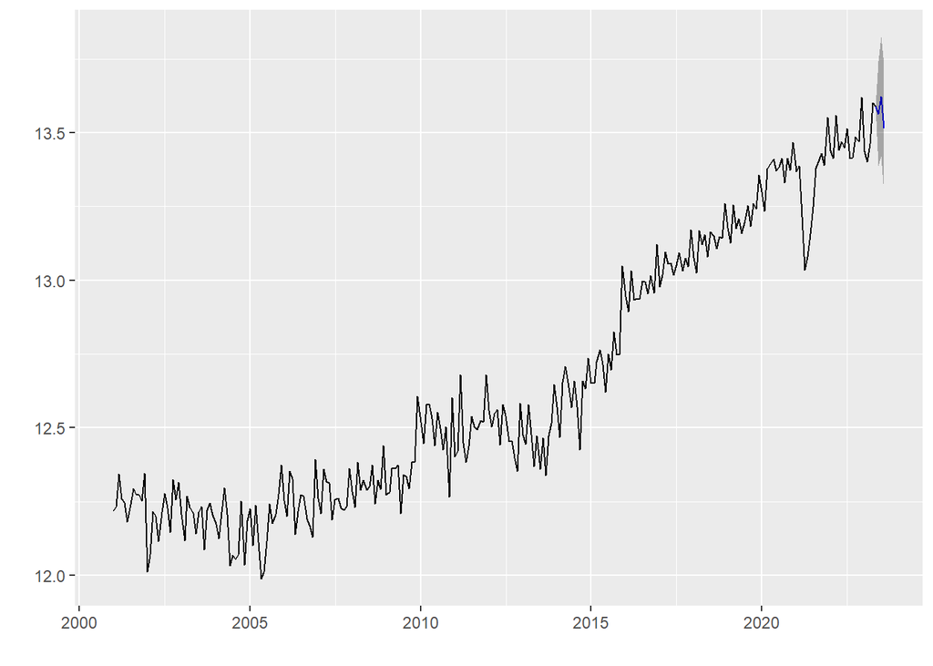

```r
fit2<-arima(log(regular_ts), c(2, 1, 1),seasonal = list(order = c(0, 1, 0), period = 12))
forecastAP3<-forecast(fit2, level = c(95), h = 3)
autoplot(forecastAP3)
```

```r
regular_ts2018<-ts( regular$`Gasolina regular`, start = c(2001,1), end=c(2020,12) ,frequency = 12)
auto.arima(regular_ts2018)
```

```
## Series: regular_ts2018
## ARIMA(0,1,1)(2,0,0)[12] with drift
##
## Coefficients:
##           ma1    sar1    sar2     drift
##       -0.5918  0.3854  0.3531  2120.435
## s.e.   0.0489  0.0610  0.0633  1607.370
##
## sigma^2 = 362527047:  log likelihood = -2696.73
## AIC=5403.46   AICc=5403.72   BIC=5420.84
```

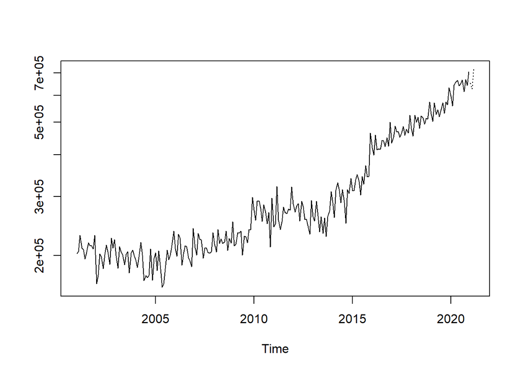

```r
fit<-arima(log(regular_ts2018), c(0, 1, 1),seasonal = list(order = c(0, 1, 1), period = 12))
pred<-predict(fit, n.ahead = 3)
ts.plot(regular_ts2018,2.718^pred$pred, log = "y", lty = c(1,3))
```

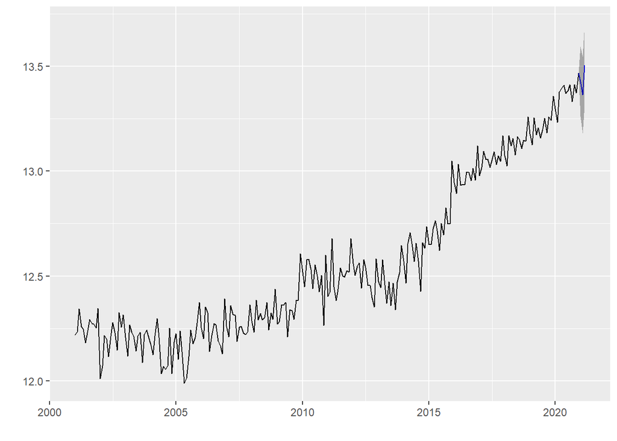

```r
fit2<-arima(log(regular_ts2018), c(2, 1, 1),seasonal = list(order = c(0, 1, 0), period = 12))
forecastAP<-forecast(fit2, level = c(95), h = 3)
autoplot(forecastAP)
```

Se concluye que la predicción hecha es buena, ya que las gráficas son muy similares a las gráficas generadas anteriormente.

#### Prophet

```r
df<-data.frame(ds=as.Date(as.yearmon(time(train))),y=as.matrix(train) )
testdf<-data.frame(ds=as.Date(as.yearmon(time(test))),y=as.matrix(test) )
head(df)
```

```
##           ds        y
## 1 2001-01-01 202645.2
## 2 2001-02-01 205531.0
## 3 2001-03-01 229499.6
## 4 2001-04-01 210680.4
## 5 2001-05-01 208164.3
## 6 2001-06-01 195088.7
```

```r
fitProphet<-prophet(df, yearly.seasonality = TRUE, weekly.seasonality = TRUE)
```

```
## Disabling daily seasonality. Run prophet with daily.seasonality=TRUE to override this.
```

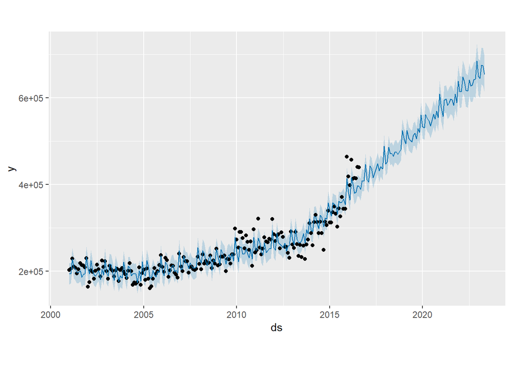

```r
future<-make_future_dataframe(fitProphet,periods = h,freq = "month", include_history = T)
p<-predict(fitProphet,future)
p<-p[,c("ds","yhat","yhat_lower","yhat_upper")]
plot(fitProphet,p)
```

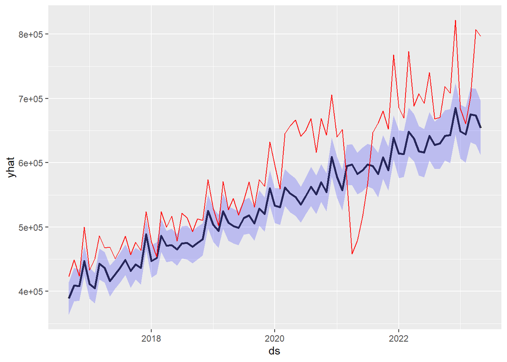

```r
pred<-tail(p,h)
pred$y<-testdf$y

ggplot(pred, aes(x=ds, y=yhat)) +
  geom_line(size=1, alpha=0.8) +
  geom_ribbon(aes(ymin=yhat_lower, ymax=yhat_upper), fill="blue", alpha=0.2) +
  geom_line(data=pred, aes(x=ds, y=y),color="red")
```

### Comportamiento durante la pandemia

Como bien sabemos, el consumo general de la gasolina disminuyó considerablemente en la pandemia por el Covid-19 porque la gente no podía salir de sus casas. Esto afectó en parte en las predicciones hechas para los tres modelos porque los datos son dependientes para poder predecir y lo comprobamos en la comparación de ambas gráficas generadas en la parte de predecir, no coincidían del todo pero la idea era la misma. Los valores habituales ya en el regreso a la “nueva normalidad” se están recuperando poco a poco, al menos la tendencia a que el consumo va incrementando se nota, sin embargo hay alguno que otro dato extremo, lo que tiene sentido porque luego de la pandemia vino la guerra entre Ucrania y Rusia lo que trajo consecuencias a todo el mundo como el alza de los precios del petróleo. Entonces no se han recuperado los datos habituales del todo en los últimos años.